# Combining expert expectations with machine learning: An analysis of bank going concern opinions before and after the financial crisis

Joshua O.S. Hunt

10/22/2021

# Genesis

- This project began at UARK
- Got a grant
- It has changed quite a bit

# Research Objectives

- Examine auditors’ behavior of issuing going concerns during and after the financial crisis
- Examine how machine learning model predictions compare to auditors going concern issuance
- Examine if combining expertise with machine learning increasing accuracy of prediction

# Prior Research - Bank & GC

- Bank failures have negative consequences
- Regulatory agencies called for action
  - Dodd-Frank
  - FDIC - adjusted CAMELS
- GC can be more severe for banks

# Predicting Bank Failure

**Meyer and Pifer (1970)**

- Small sample: Training 30 and Testing 9
- Matched Sample
- 1948 - 1965
- Ordinary Least Squares: LPM

**Thomson (1991)**

- Predicts 1, 2 , 3 years ahead with 1 year of training data
- 1982-1989
- Logistic Regression

**Wheelock and Wilson (2005)**

- Association study
- 1987-1999
- Cox Proportional Hazard Model

**Estrella, Park, and Perstiani (2000)**

- Association study
- 1988-1993
- Cox Proportional Hazard Model and Logistic (by year)

**Cole and White (2012)**

- Association and Prediction Training 2008-2009 and Testing q1-q3 in 2010
- 2004-2009
- Logistic Regression

**Ng and Roychowdhury (2014)**

- Association
- 2001-2010
- Logistic Regression and Hazard models

**Kosimidou and Zopounidis (2008)**

- Training 1993-1999 and Testing 2000-2003
- Discriminant analysis and UTADIS
- Matched samples

**Not an exhaustive list**

# Prior Research Issues

- Quarterly
- Association
- Matched sample
- Reports true positive rate as accuracy

# Research Method Overview

- Training sample starts 2003 and the testing sample ends in 2019
- Rolling 3 year windows
- Predict Bank Failures
- Sample has auditor, bank, and return information

# GC and Bank Failures

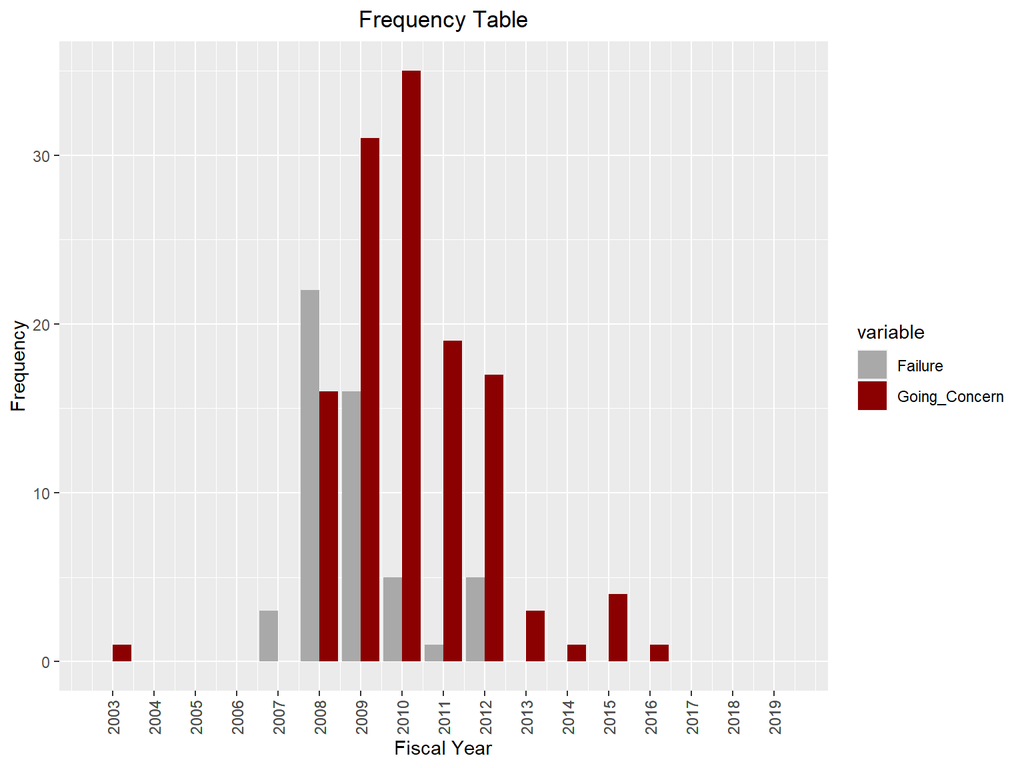

# GC and Bank Failures

| Fiscal Year | Bank Failure | Going Concern |
| --- | --- | --- |
| 2003 | 0 | 1 |
| 2004 | 0 | 0 |
| 2005 | 0 | 0 |
| 2006 | 0 | 0 |
| 2007 | 3 | 0 |
| 2008 | 22 | 16 |
| 2009 | 16 | 31 |
| 2010 | 5 | 35 |
| 2011 | 1 | 19 |
| 2012 | 5 | 17 |
| 2013 | 0 | 3 |
| 2014 | 0 | 1 |
| 2015 | 0 | 4 |
| 2016 | 0 | 1 |
| 2017 | 0 | 0 |
| 2018 | 0 | 0 |
| 2019 | 0 | 0 |

# Hypothesis 1

**H1**: *Regulatory and market scrutiny had no effect on the auditors’ propensity to issue a going concern after the financial crisis relative to during crisis.*

# H1 Confusion During

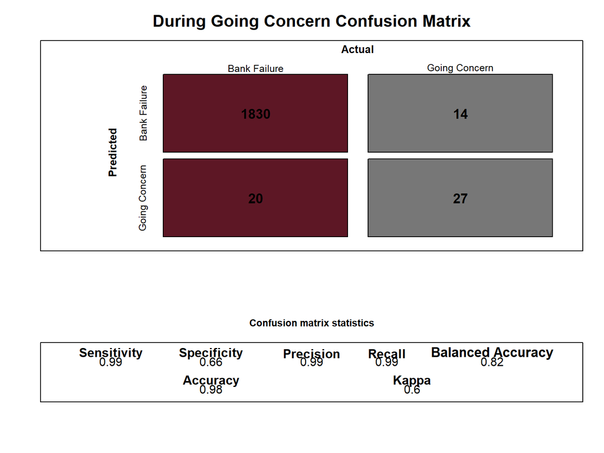

# H1 Confusion Post

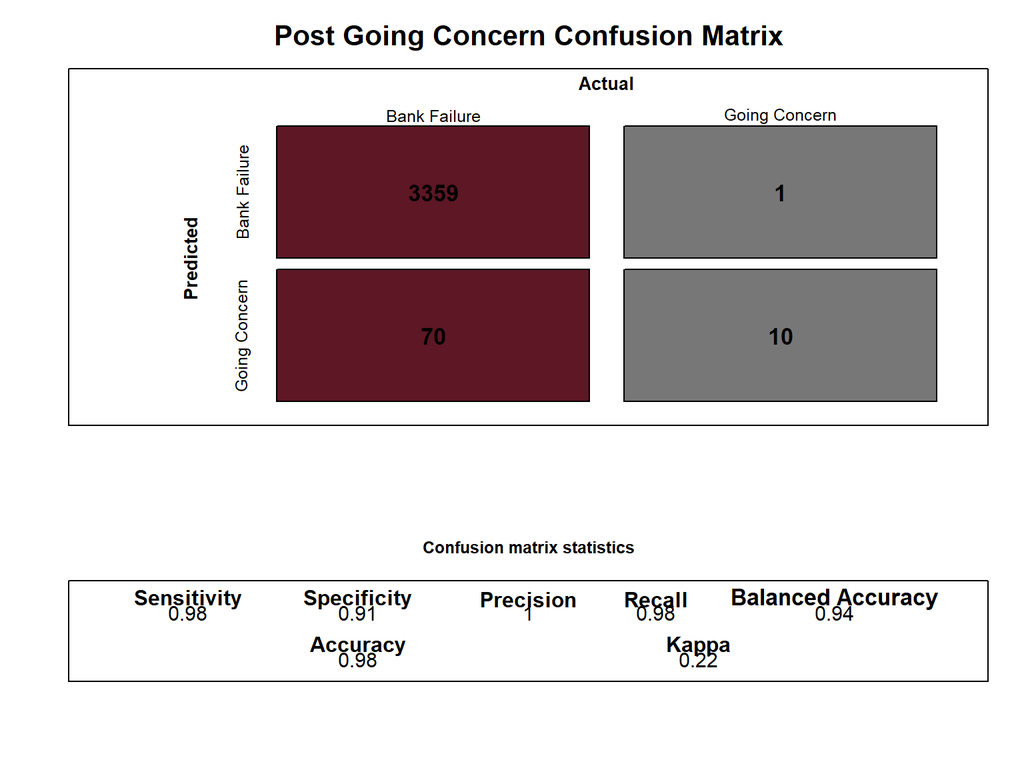

# Hypothesis 1 Results

During Crisis

| Bank Failure | Going Concern | Freq |
| --- | --- | --- |
| 0 | 0 | 1830 |
| 1 | 0 | 14 |
| 0 | 1 | 20 |
| 1 | 1 | 27 |

Post Crisis

| Bank Failure | Going Concern | Freq |
| --- | --- | --- |
| 0 | 0 | 3359 |
| 1 | 0 | 1 |
| 0 | 1 | 70 |
| 1 | 1 | 10 |

# H1 Test of Significance

```r
prop.test(x=c(47,80), n=c(1830+14+20+27, 3359+1+70+10),
          conf.level=0.9)
```

```
##
##  2-sample test for equality of proportions with continuity correction
##
## data:  c(47, 80) out of c(1830 + 14 + 20 + 27, 3359 + 1 + 70 + 10)
## X-squared = 0.074179, df = 1, p-value = 0.7853
## alternative hypothesis: two.sided
## 90 percent confidence interval:
##  -0.006059585  0.009257106
## sample estimates:
##     prop 1     prop 2
## 0.02485457 0.02325581
```

# H1 Test of Significance

```r
prop.test(x=c(20,70), n=c(1830+14+20+27, 3359+1+70+10),
          conf.level=0.99)
```

```
##
##  2-sample test for equality of proportions with continuity correction
##
## data:  c(20, 70) out of c(1830 + 14 + 20 + 27, 3359 + 1 + 70 + 10)
## X-squared = 6.4447, df = 1, p-value = 0.01113
## alternative hypothesis: two.sided
## 99 percent confidence interval:
##  -0.0188520047 -0.0006928405
## sample estimates:
##     prop 1     prop 2
## 0.01057641 0.02034884
```

# Unsupervised Learning

Models learn with only one class, the banks that do not fail. Bank failure is an anomaly. Anomalies should not be view as a percentage of the sample. For the first part of our sample traditional models cannot be used.

# Isolation Forest

- Ensemble of decision trees
- Random sample and input
- Continues until each point is isolated
- Prediction: deeper the observation more likely an anomaly

# One-Class Support Vector Machine

- Like a normal support vector machine except the origin is a class
- Separate two classes with a hyperplane
- Kernel for non-linearity
- svm points and error

# Hypothesis 2

**H2**: *Bank failure prediction accuracy is similar between auditors and machine learning methods.*

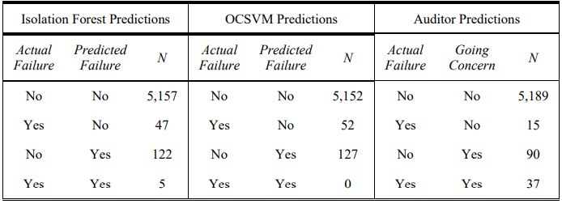

# Hypothesis 3

**H3**: *Combining auditor and machine learning bank failure predictions improves going concern opinion false positive rate.*

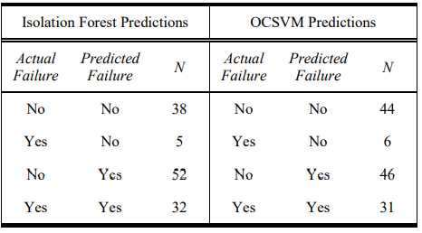

# Conclusion

1. Anomaly Detection
2. Auditors do a good job
3. Auditors with ML can do a better job

# Additional Analysis

- Two modules perform similarly
- Bailouts not an issue
- Distress only similar, but less false positives
- GC in the model does not help

# Difference in Means

Variables

Actual

Predicted

Diff

PValue

Sig

TValue

stock_return

0.841

-0.614

>

0.0768

.

1.77

total_assets

20226432.634

1962266.231

>

<1e-06

***

9.814

total_loans

10555389.963

1364199.269

>

<1e-06

***

9.985

net_loans

10186660.073

1243330.865

>

<1e-06

***

10.206

CAP

0.135

0.06

>

<1e-06

***

8.086

PSLOANS

0.701

0.827

<

1.97e-06

***

-5.354

NPL

0.015

0.083

<

<1e-06

***

-9.974

C_I

2280596.62

142303.596

>

<1e-06

***

11.386

GCOMM

0.119

0.08

>

0.00023

***

3.955

all_other_real_estate

5463384.824

1159036.135

>

<1e-06

***

8.305

GRESTATE

0.052

-0.048

>

<1e-06

***

6.116

GLOANS

0.068

-0.063

>

<1e-06

***

7.052

direct_leasefin

206766.756

3354.192

>

<1e-06

***

10.807

LOAN_MIX

0.912

0.977

<

<1e-06

***

-17.563

SIZE

14.191

13.537

>

0.00157

3.336

CA_TA

0.051

0.095

<

0.000297

***

-3.881

RE_TA

0.032

-0.078

>

7.86e-06

***

4.972

EQ_TA

0.106

0.05

>

<1e-06

***

16.121

ROA

0.005

-0.049

>

<1e-06

***

10.192

LOAN1

0.663

0.7

<

0.0104

-2.659

LOAN2

1.525

0.838

>

0.0195

2.336

LOAN3

0.921

0.757

>

0.00258

3.016

LOANQUAL2

0.016

0.04

<

<1e-06

***

-8.925

LOANQUAL3

0.007

0.041

<

<1e-06

***

-9.278

TOTAL_CAP

0.148

0.075

>

<1e-06

***

7.882

off_bs

0.159

0.041

>

<1e-06

***

20.097

unearned_income

1211.014

647.192

>

0.0186

2.39

tot_int_inc

655761.16

107654.404

>

<1e-06

***

8.892

tot_nonint_inc

355821.287

9931.673

>

<1e-06

***

10.133

net_income

177444.143

-70691.596

>

<1e-06

***

9.08

charge_off_on_allowance_ll

99865.181

60803.692

>

0.0494

1.99

tot_int_exp

145700.359

54531.596

>

6.05e-05

***

4.101

tot_nonint_exp

533482.749

65668.096

>

<1e-06

***

9.1

provision_loanloss

85511.303

77720.115

>

0.732

0.344

net_income_pre_ops

177612.243

-70691.385

>

<1e-06

***

9.084

OREO

25402.316

28945.865

<

0.69

-0.401

PChg_total_assets

0.098

-0.023

>

<1e-06

***

5.82

PChg_total_loans

0.103

-0.08

>

<1e-06

***

8.009

PChg_net_loans

0.104

-0.101

>

<1e-06

***

8.568

PChg_CAP

0.21

-0.295

>

<1e-06

***

7.559

PChg_PSLOANS

0.048

0.461

<

0.00295

-3.12

PChg_NPL

1.986

11.108

<

0.134

-1.522

PChg_C_I

0.138

-0.071

>

<1e-06

***

5.534

PChg_GCOMM

0.06

-0.109

>

9.61e-06

***

4.762

PChg_all_other_real_estate

0.179

-0.071

>

3.66e-06

***

4.65

PChg_GRESTATE

5.165

-0.575

>

0.025

2.249

PChg_GLOANS

1.507

-2.033

>

0.0173

2.383

PChg_LOAN_MIX

0.005

0.002

>

0.198

1.29

PChg_SIZE

0.005

-0.003

>

2.29e-06

***

5.31

PChg_CA_TA

0.258

3.113

<

0.00526

-2.916

PChg_RE_TA

-0.346

-11.551

>

0.0945

.

1.704

PChg_EQ_TA

0.024

-0.401

>

<1e-06

***

11.781

PChg_ROA

0.009

-6.824

>

0.000176

***

3.979

PChg_LOAN1

0.006

-0.082

>

<1e-06

***

6.638

PChg_LOAN2

0.003

-0.126

>

<1e-06

***

8.072

PChg_LOAN3

0.004

-0.123

>

<1e-06

***

8.481

PChg_LOANQUAL2

0.067

0.798

<

<1e-06

***

-6.392

PChg_LOANQUAL3

4.125

77.475

<

0.268

-1.121

PChg_TOTAL_CAP

0.21

-0.252

>

<1e-06

***

7.055

PChg_off_bs

2.774

-0.162

>

0.276

1.089

PChg_tot_int_inc

0.079

-0.169

>

<1e-06

***

11.108

PChg_tot_nonint_inc

0.27

-1.96

>

0.0481

2.025

PChg_net_income

0.662

-6.547

>

0.000185

***

3.901

PChg_tot_int_exp

0.028

-0.147

>

<1e-06

***

5.851

PChg_tot_nonint_exp

0.136

0.528

<

0.0405

-2.102

PChg_net_income_pre_ops

0.163

-6.818

>

0.000212

***

3.892

PUBLIC

0.019

0

>

<1e-06

***

10.827

Q2Disclosure

0.006

0

>

<1e-06

***

6.265

Q3Disclosure

0.004

0.038

<

0.207

-1.279

Q4Disclosure

0.032

0.019

>

0.508

0.666

distress_masli

0.131

0.962

<

<1e-06

***

-30.46

Confidential

0

0

<

NA

NaN

Nonconfidential

0.054

0.096

<

0.312

-1.02

call

0.022

0.019

>

0.888

0.141

deposits

0.013

0.038

<

0.517

-0.653

effective

0.009

0

>

<1e-06

***

7.386

fdic

0.011

0.019

<

0.671

-0.427

report

0.022

0.019

>

0.888

0.141

loan

0.012

0

>

<1e-06

***

5.513

loans

0.018

0

>

<1e-06

***

7.59

quarter

0.012

0

>

<1e-06

***

7.395

assets

0.011

0.019

<

0.671

-0.427

bank

0.047

0.019

>

0.168

1.395

banks

0.016

0.019

<

0.881

-0.15

due

0.011

0.038

<

0.322

-1

million

0.016

0.038

<

0.571

-0.571

capital

0.017

0.038

<

0.58

-0.557

schedule

0.01

0.019

<

0.652

-0.453

line

0.01

0

>

<1e-06

***

6.052

reported

0.008

0.019

<

0.568

-0.575

december

0.01

0

>

<1e-06

***

6.018

# Paper

[figure not shown]

# Test

This is an example of toggle buttons

Goes with 1

Goes with 2